# Logistic Regression Activity

Dale Barr

# Instructions

Leave everything above this section in the file. This RMarkdown file should be in your working directory as an .Rmd file with the binary data file you’ll be working with (`trials.rds`).

You should then set your working directory for the console to point to this same location (from the pulldown menu, select Session | Set Working Directory…). Instead of at the end of the document, validation code appears directly under each problem. Make sure the validation code passes (returns `TRUE` for all tests) before moving onto the next step.

# Background

In this experiment, speakers were asked to describe unusual complicated shapes, like those seen in the set below:

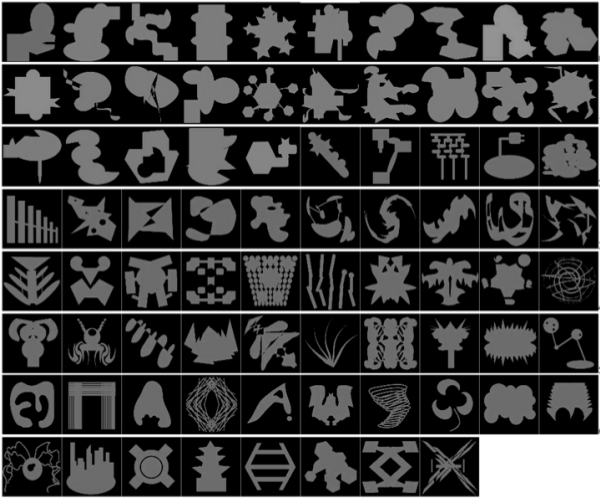

In each trial of the experiment, participants saw a pair of pictures on the screen from the image set, and had to name one of the two pictures so that a listener could select is using a computer mouse. Because these pictures were hard to describe, speakers would often hesitate and produce so-called “fillers” (“um” or “uh”) preceding their descriptions. For instance, a speaker might say:

> [480 ms silence] um.. [1022 ms silence] it looks like three snails stacked up

Note that there are pauses (measured in milliseconds) preceding and following the filler (in the example, ’um’). Your task in this assignment is to investigate the properties that cause speakers to produce fillers, as well as the factors that govern the choice of filler type (’um’ versus ’uh’).

Each picture was named three times (pictures get easier to describe each time, so the prediction would be that fillers get less likely).

The main topic we want to investigate is the relationship between fillers and hesitation pauses. We want to know: do fillers become more likely with longer pauses?

If you want to learn more about these issues, please consult the following article:

Clark, H. H., and Fox Tree, J. (2002). Using ‘uh’ and ‘um’ in spontaneous speaking. *Cognition*, 84, 73–111.

Note: This is multilevel data, with repeated sampling over participants (`subj_id`) and pictures (`pic_id`).

- `trials.rds`

Information about individual trials

| column | description |
| --- | --- |
| subj_id | unique number identifying each subject |
| nat | nationality (Amer= American or Dutch) |
| trial_id | unique number identifying each trial |
| pic_id | unique number identifying each picture |
| prev_men | number of times picture was previously named by subject |
| filler | identity of filler that was produced: no = no filler; uh,um; ot= other |
| onset | latency onset of first (non-filler) word in the description (milliseconds) |

## Set up your session

In the code chunk provided below, load in any packages you need and import the data from `trials.rds` using the `readRDS()` function.

```r
## setup
library("tidyverse")
library("lme4")

trials <- readRDS("trials.rds")
```

## Task 1

Before proceeding, remove all fillers of type ‘ot’ (other) from the dataset. Store the resulting table in the variable `tclean`. Use this as your source dataset in the following blocks.

```r
## get rid of all fillers of type 'ot'
tclean <- trials %>%
  filter(filler != "ot")
```

### Validation of `T01`

- `tclean` exists and is has correct column names: TRUE

## Task 2

How many fillers of each type are in your dataset? The result `n_types` should be a table with exactly two columns named `filler` and `n` of types `character` and `integer`, respectively.

```r
n_types <- count(tclean, filler)
```

### Validation of `T02`

- `n_types` exists and has columns `filler` and `n`: TRUE

## Task 3

We are going to attempt to model the probability of a filler of any type (um or uh) as a function of the length of the pause preceding the first content word, as given by the variable `onset`.

The first thing that we should do is express onset in seconds rather than milliseconds. Using a tidyverse function, add a new column to `tclean` called `onset_s` which expresses `onset` in seconds, rather than milliseconds. Store the resulting table in `tclean2`.

```r
tclean2 <- tclean %>%
  mutate(onset_s = onset / 1000)
```

### Validation of `T03`

- `tclean2` exists and has column `onset_s`: TRUE

## Task 4

Let’s have a look at the distribution of `onset_s` in the dataset `tclean2`. Write code to create the graph below.

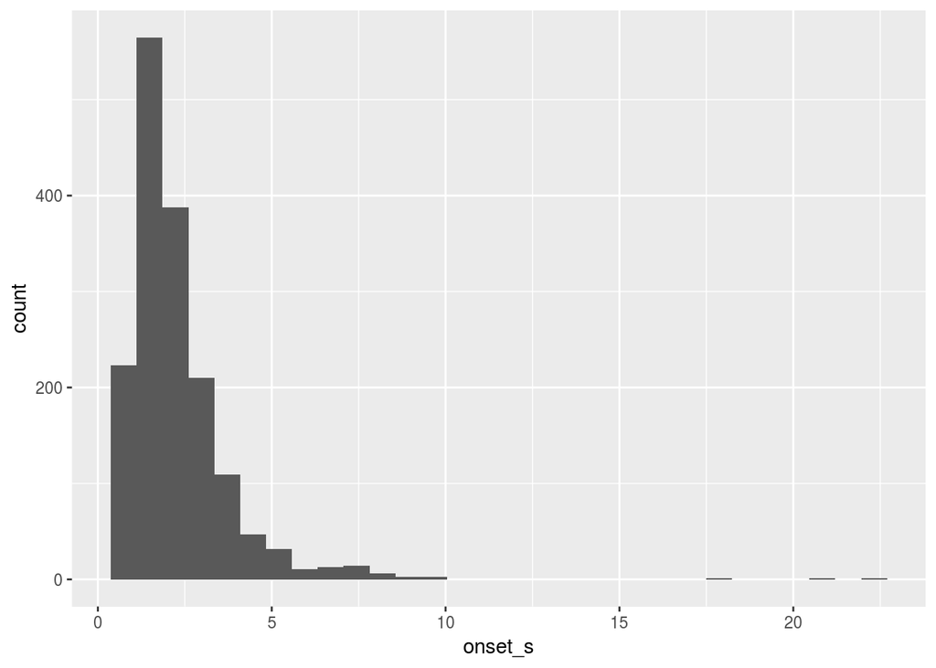

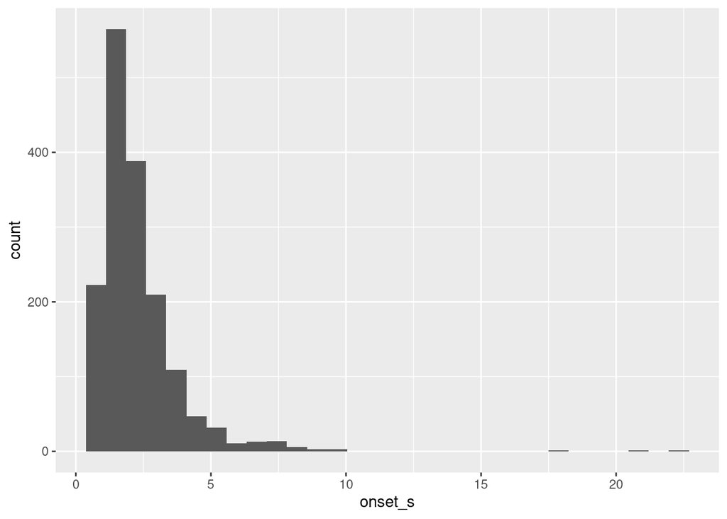

```r
## TODO: your ggplot code here
ggplot(tclean2,
       aes(onset_s)) + geom_histogram()
```

## Task 5

OK, that distribution does not look ideal. Create a new variable in the `tclean2` dataset called `onset_slog` that is the log of `onset_s`, and store the resulting table in `tclean3`. Plot the distribution of `onset_slog`.

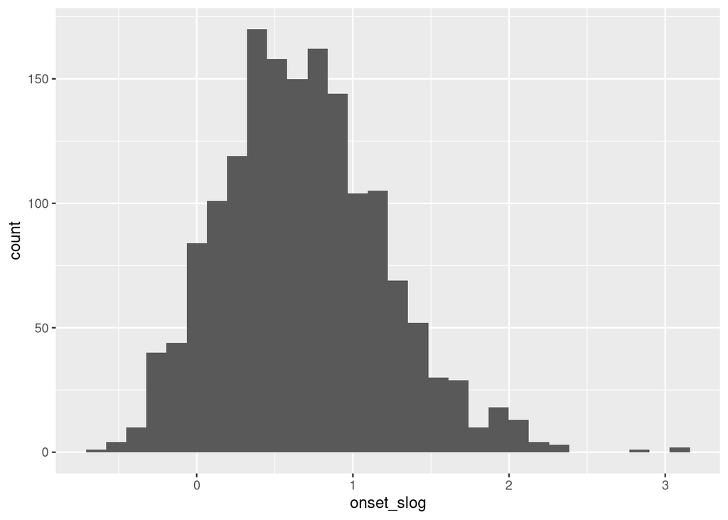

```r
tclean3 <- tclean2 %>%
  mutate(onset_slog = log(onset_s))

## TODO: your ggplot code here
ggplot(tclean3, aes(onset_slog)) + geom_histogram()
```

That looks much better! We will use `onset_slog` in our modeling.

### Validation of `T05`

- `tclean3` exists and has column `onset_slog`: TRUE

## Task 6

What we want to do next is to model the probability of a filler as a function of the length of the surrounding pause.

The variable containing the behavior you want to model is `filler`, which has three levels. But to fit a logistic regression model, you first need a *dichotomous* response variable—a variable that has two categories. Recode `filler` from `tclean3` into a new variable `anyfill` of type integer or numeric (*not* factor), which codes ‘um’ or ‘uh’ as `1` and ‘no’ as `0`. The resulting table should be stored in the variable `tclean_af`.

*HINT*: `recode()`, `if_else()`, `case_when()`

```r
tclean_af <- tclean3 %>%
  mutate(anyfill = if_else(filler == "no", 0L, 1L))
```

### Validation of `T06`

- `tclean_af` exists and has column `anyfill`: TRUE

## Task 7

Categorical data can be difficult to visualize, because they are fundamentally just 1s and 0s, but it is important to nonetheless get some idea about the pattern you are trying to model before you go any further.

The main problem with categorical variable is that for each `x` observation (`onset`), you have a single `0` or `1` outcome variable. It would be nice to plot proportions of “successes”" (e.g., producing a filler) but we can’t do this for individual `x` values; however, we can do it for a *range* of `x` values.

One common strategy to *bin* your predictor variable, which means breaking it into ranges and calculating an aggregate value for the range.

To understand how to bin data, study the code below, which bins up data from an example table and plots it.

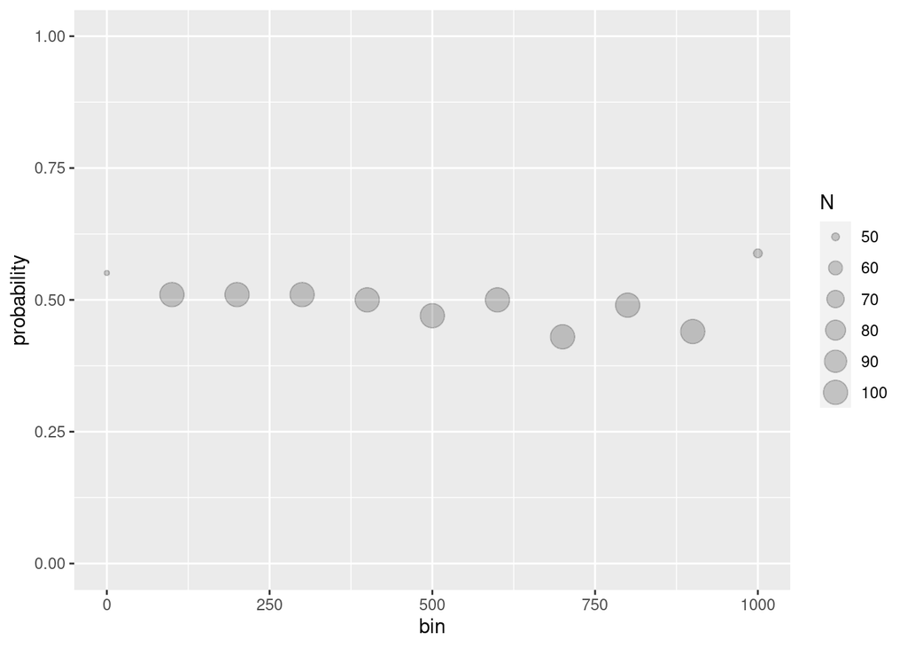

```r
## THIS CODE BLOCK GIVES AN EXAMPLE; IT IS NOT PART OF THE ASSESSMENT
example_data <- tibble(time_ms = 1:1000,
                       y = sample(0:1, 1000, TRUE))

## put the data into 100 ms bins
binned <- example_data %>%
  mutate(bin = floor((time_ms + 50) / 100) * 100)

bin_sum <- binned %>%
  group_by(bin) %>%
  summarise(p = mean(y), N = n())

ggplot(bin_sum, aes(bin, p)) +
  geom_point(aes(size = N), alpha = .2) +
  coord_cartesian(ylim = c(0, 1)) +
  labs(y = "probability")
```

Based on the example above, use the `tclean_af` table, bin up `onset_slog` into bins with bin size of .25 (call the binned variable `onset_bin`), and calculate the probability of a filler (`p`) for each bin. The resulting table should contain `onset_bin` and `p`, and should be named `tclean_bin`.

```r
tclean_bin <- tclean_af %>%
  mutate(onset_bin = floor((onset_slog + .125) / .25) * .25) %>%
  group_by(onset_bin) %>%
  summarise(p = mean(anyfill), N = n())
```

### Validation of `T07`

- `tclean_bin` exists and has columns `onset_bin` and `p`: TRUE

## Task 8

Make a plot like the one above, showing `p` as a function of `onset_bin`.

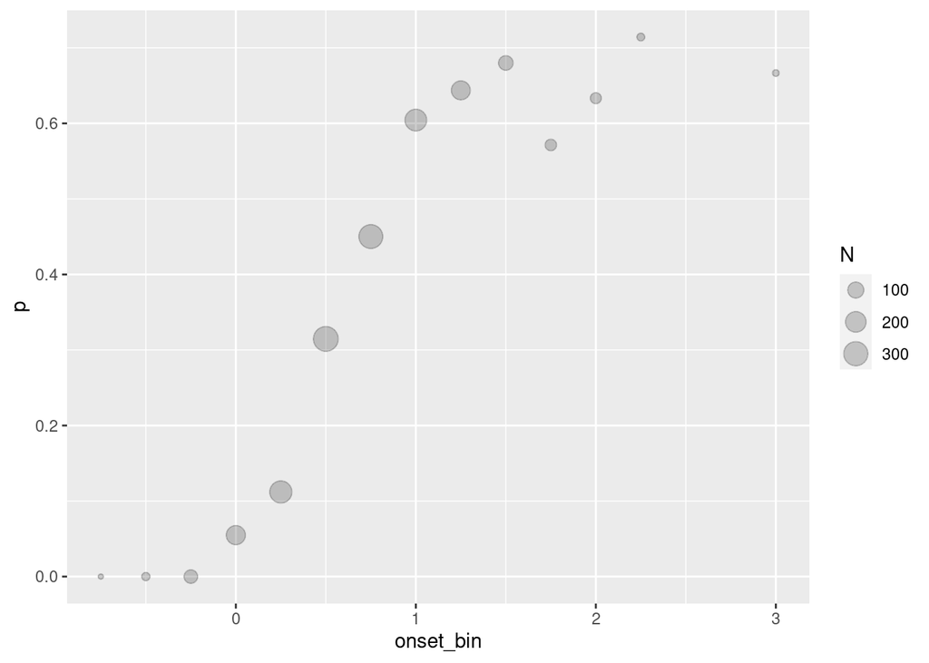

```r
g <- ggplot(tclean_bin, aes(onset_bin, p)) +
  geom_point(aes(size = N), alpha = .2)

g
```

## Task 9

Fit a logistic regression on the dataset `tclean_af` with `anyfill` as the response measure and `onset_slog` as the predictor, with appropriate by-subject and by-picture random effects. The resulting model *must* be stored in `mod`.

```r
mod <- glmer(anyfill ~ onset_slog +
               (onset_slog | subj_id) +
               (onset_slog | pic_id),
             binomial(link = "logit"), data = tclean_af)
```

```r
summary(mod)
```

```
## Generalized linear mixed model fit by maximum likelihood (Laplace
##   Approximation) [glmerMod]
##  Family: binomial  ( logit )
## Formula: anyfill ~ onset_slog + (onset_slog | subj_id) + (onset_slog |
##     pic_id)
##    Data: tclean_af
##
##      AIC      BIC   logLik deviance df.resid
##   1408.9   1452.1   -696.5   1392.9     1619
##
## Scaled residuals:
##     Min      1Q  Median      3Q     Max
## -6.7054 -0.4501 -0.1838  0.3674  5.6133
##
## Random effects:
##  Groups  Name        Variance  Std.Dev. Corr
##  subj_id (Intercept) 2.214e+00 1.487788
##          onset_slog  5.585e+00 2.363271 -0.39
##  pic_id  (Intercept) 1.301e-05 0.003608
##          onset_slog  5.499e-02 0.234507 -0.99
## Number of obs: 1627, groups:  subj_id, 36; pic_id, 22
##
## Fixed effects:
##             Estimate Std. Error z value Pr(>|z|)
## (Intercept)  -3.8130     0.3351 -11.377   <2e-16 ***
## onset_slog    4.8293     0.4999   9.661   <2e-16 ***
## ---
## Signif. codes:  0 '***' 0.001 '**' 0.01 '*' 0.05 '.' 0.1 ' ' 1
##
## Correlation of Fixed Effects:
##            (Intr)
## onset_slog -0.591
```

### Validation of `T09`

- `mod` exists and is of type `merMod`: TRUE